# Online Shopping Behavior

11/7/2019

## Introduction

The internet shopping particulary in business to consumer(B2C) has risen and online shopping has become more popular to many people.

**Objective**

- To understand the consumers’ perception and shopping behavior toward online retail
- To find out the buying pattern of consumers while shopping online
- To study relevance between the consumer buying decision with respect to price, time, demography and so on
- To make the successful business strategy knowledge of consumer perception

## Dateset

Primary data is to be collected from the respondents with the help of a structured questionnaire  
Sample Size: 117 parcitipants  
Method: Convenience sampling  
Tool: Quentionnaire  
Techinique: Online Survey - Social media and friends  
Independent Variable: age, gender, marital status, occupation and income  
Dependent Variable: variables related to consumer behaviors

## Data Visualization

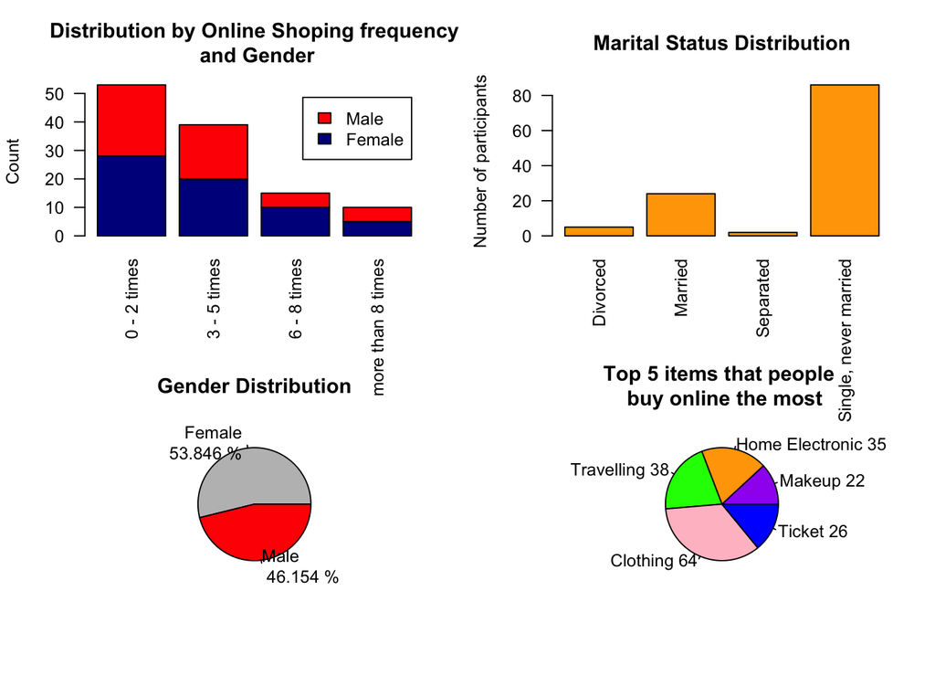

## Chi-square Test

To test if there is a statistically significant correlation between gender and their online shopping behavior, we can use a chi-squared test of independence.

Hypothesis  
H<sub>0</sub> : Gender and their online shopping behavior are independent  
H<sub>a</sub> : Gender and their online shopping behavior are dependent

```
##
##          no yes
##   Female 13  50
##   Male    5  49
```

```
##
##  Pearson's Chi-squared test
##
## data:  table(shop$Gender, shop$Shop_Online)
## X-squared = 2.8905, df = 1, p-value = 0.08911
```

Since p-value is greater than 0.05, there is no significant evidences to say that there is difference between male and female related to their behavior toward online shoping.

## Chi-square Test

To test if there is a statistically significant correlation between privacy concern and people behvior on online shopping, we can use a chi-squared test of independence.

Hypothesis  
H<sub>0</sub> : Privacy concern and online shopping behavior are independent  
H<sub>a</sub> : Privacy concern and online shopping behavior are dependent

```
##
##       Shopping in store Shopping online
##   no                 26              51
##   yes                15              25
```

```
##
##  Pearson's Chi-squared test
##
## data:  table(shop$Privacy_Concern, shop$Shopping_Preferrence)
## X-squared = 0.16123, df = 1, p-value = 0.688
```

Since p-value is greater than 0.05, there is no enough evidence to conclude that privacy concern affect the online shopping behavior of people.

## Correlation Between the Variables

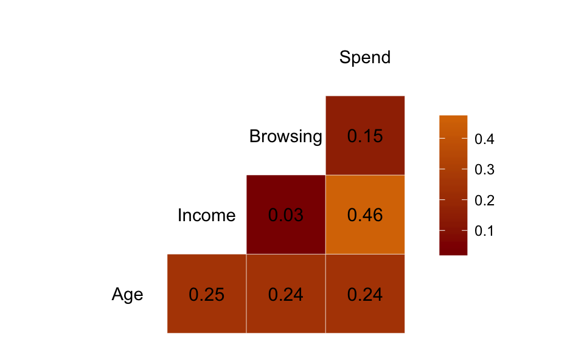

The Pearson correlation coefficient indicates a moderate *linear* correlation between spending and monthly income.

## Linear Regression Model

**Model 1 : Shopping_MoneySpent_Monthly = Age + Monthly_Income + Browsing_Time**

```
##
## Call:
## lm(formula = Shopping_MoneySpent_Monthly ~ Age + Monthly_Income +
##     Browsing_Time, data = d1)
##
## Residuals:
##     Min      1Q  Median      3Q     Max
## -409.57 -101.47  -42.47   42.43 1233.02
##
## Coefficients:
##                  Estimate Std. Error t value  Pr(>|t|)
## (Intercept)    -78.643147  91.928600  -0.855     0.394
## Age              3.551249   3.095718   1.147     0.254
## Monthly_Income   0.030412   0.006526   4.660 0.0000104 ***
## Browsing_Time    9.550036   8.161936   1.170     0.245
## ---
## Signif. codes:  0 '***' 0.001 '**' 0.01 '*' 0.05 '.' 0.1 ' ' 1
##
## Residual standard error: 230.3 on 94 degrees of freedom
## Multiple R-squared:  0.243,  Adjusted R-squared:  0.2188
## F-statistic: 10.06 on 3 and 94 DF,  p-value: 0.000008232
```

## Linear Regression Model

**Model 2 Shopping_MoneySpent_Monthly = Monthly_Income**

```
##
## Call:
## lm(formula = Shopping_MoneySpent_Monthly ~ Monthly_Income, data = d1)
##
## Residuals:
##     Min      1Q  Median      3Q     Max
## -373.07  -93.59  -52.52   55.88 1217.56
##
## Coefficients:
##                 Estimate Std. Error t value   Pr(>|t|)
## (Intercept)    54.400168  38.905858   1.398      0.165
## Monthly_Income  0.032578   0.006364   5.119 0.00000158 ***
## ---
## Signif. codes:  0 '***' 0.001 '**' 0.01 '*' 0.05 '.' 0.1 ' ' 1
##
## Residual standard error: 232.1 on 96 degrees of freedom
## Multiple R-squared:  0.2144, Adjusted R-squared:  0.2062
## F-statistic:  26.2 on 1 and 96 DF,  p-value: 0.000001579
```

## Compare model 1 and 2

```
## Analysis of Variance Table
##
## Model 1: Shopping_MoneySpent_Monthly ~ Age + Monthly_Income + Browsing_Time
## Model 2: Shopping_MoneySpent_Monthly ~ Monthly_Income
##   Res.Df     RSS Df Sum of Sq      F Pr(>F)
## 1     94 4984680
## 2     96 5172940 -2   -188260 1.7751 0.1751
```

We compare these two models using anova. As can be seen, the p-vlaue is greater than 0.05,and we can say there is no difference between these two models. This means we just need one predictor which is Monthly_Income to predict the outcome of our model.

## Limitation

**External Validity**

- Online survey
- Convinience sampling
- Not representative

**Internal Validity**

- Sample size was only 117
- The age range was not diverse which would also affect IV such as income and marital status
- Some of the participants didn’t complete the survey

## Conclusion

**Learning**

**Future Research**

- Enhance sampling size to improve external validity
- Choose random sampling instead of convience sampling to achieve diversity

## References

- Kabacoff, Robert I. “Quick-R by DataCamp.” 2017. Sitemap. 5 December 2019. https://www.statmethods.net/graphs
- “Chi-Square Test in R | Explore the Examples and Essential concepts!” 10 July 2019. Data Flair. 4 December 2019. https://data-flair.training/blogs/chi-square-test-in-r/
- Xie, Yihui. “Title slide.” 12 May 2019. GitHub. 5 December 2019. https://github.com/yihui/xaringan/wiki/Title-slide
- Porras, Eladio Montero. “Linear Regression in R.” 18 July 2018. Data Camp. 5 December 2019. https://www.datacamp.com/community/tutorials/linear-regression-R